# Predicting Income using LASSO, Ridge and Elastic Net Regularization methods

INSOFE Lab

28 July, 2018

*Formulae :* AIC for a Regression problem:
$$AIC = 2k + n*Log(RSS/n)$$

- RSS - Residual Sum of Squares
- n - Number of training examples
- k - Number of attributes/independent variables/ predictor variables/ features

# First things first

- Clear the environment
- You might want to comment this line if you are working on multiple datasets/problems to avoid accidental removal of objects from the environment

```r
rm(list=ls())
```

# Read and Understand the data

```r
df <- read.delim("./UnivBank.csv",sep = ",",na.strings = c(""," ","?","#"))

str(df)
```

```
## 'data.frame':    5000 obs. of  14 variables:
##  $ ID                : int  1 2 3 4 5 6 7 8 9 10 ...
##  $ Age               : int  25 45 39 35 35 37 53 50 35 34 ...
##  $ Experience        : int  1 19 15 9 8 13 27 24 10 9 ...
##  $ Income            : int  49 34 11 100 45 29 72 22 81 180 ...
##  $ ZIP.Code          : int  91107 90089 94720 94112 91330 92121 91711 93943 90089 93023 ...
##  $ Family            : int  4 3 1 1 4 4 2 1 3 1 ...
##  $ CCAvg             : num  1.6 1.5 1 2.7 1 0.4 1.5 0.3 0.6 8.9 ...
##  $ Education         : int  1 1 1 2 2 2 2 3 2 3 ...
##  $ Mortgage          : int  0 0 0 0 0 155 0 0 104 0 ...
##  $ Personal.Loan     : int  0 0 0 0 0 0 0 0 0 1 ...
##  $ Securities.Account: int  1 1 0 0 0 0 0 0 0 0 ...
##  $ CD.Account        : int  0 0 0 NA 0 0 0 0 0 0 ...
##  $ Online            : int  0 0 0 0 0 1 1 0 1 0 ...
##  $ CreditCard        : int  0 0 0 0 1 0 0 1 0 0 ...
```

```r
summary(df)
```

```
##        ID            Age          Experience       Income
##  Min.   :   1   Min.   :23.00   Min.   :-3.0   Min.   :  8.00
##  1st Qu.:1251   1st Qu.:35.00   1st Qu.:10.0   1st Qu.: 39.00
##  Median :2500   Median :45.00   Median :20.0   Median : 64.00
##  Mean   :2500   Mean   :45.34   Mean   :20.1   Mean   : 73.77
##  3rd Qu.:3750   3rd Qu.:55.00   3rd Qu.:30.0   3rd Qu.: 98.00
##  Max.   :5000   Max.   :67.00   Max.   :43.0   Max.   :224.00
##
##     ZIP.Code         Family          CCAvg          Education
##  Min.   : 9307   Min.   :1.000   Min.   : 0.000   Min.   :1.000
##  1st Qu.:91911   1st Qu.:1.000   1st Qu.: 0.700   1st Qu.:1.000
##  Median :93437   Median :2.000   Median : 1.500   Median :2.000
##  Mean   :93152   Mean   :2.396   Mean   : 1.938   Mean   :1.881
##  3rd Qu.:94608   3rd Qu.:3.000   3rd Qu.: 2.500   3rd Qu.:3.000
##  Max.   :96651   Max.   :4.000   Max.   :10.000   Max.   :3.000
##
##     Mortgage      Personal.Loan   Securities.Account   CD.Account
##  Min.   :  0.00   Min.   :0.000   Min.   :0.0000     Min.   :0.00000
##  1st Qu.:  0.00   1st Qu.:0.000   1st Qu.:0.0000     1st Qu.:0.00000
##  Median :  0.00   Median :0.000   Median :0.0000     Median :0.00000
##  Mean   : 56.52   Mean   :0.096   Mean   :0.1044     Mean   :0.06041
##  3rd Qu.:101.00   3rd Qu.:0.000   3rd Qu.:0.0000     3rd Qu.:0.00000
##  Max.   :635.00   Max.   :1.000   Max.   :1.0000     Max.   :1.00000
##  NA's   :2                        NA's   :2          NA's   :1
##      Online         CreditCard
##  Min.   :0.0000   Min.   :0.000
##  1st Qu.:0.0000   1st Qu.:0.000
##  Median :1.0000   Median :0.000
##  Mean   :0.5968   Mean   :0.294
##  3rd Qu.:1.0000   3rd Qu.:1.000
##  Max.   :1.0000   Max.   :1.000
##
```

## Data Description

- Name : Description
- ID : Customer ID
- Age : Customer’s age in completed year
- Experience : # years of professional experience
- Income : Annual income of the customer (1,000)
- ZIPcode : Home address ZIP code
- Family : Family size of the customer
- CCAvg : Average monthly credit card spending (1, 000)
- Education : Education level: 1: undergrad; 2, Graduate; 3; Advance/Professional
- Mortgage : Value of house mortgage if any (1, 000)
- Personal loan : Did this customer accept the personal loan offered in he last - campaign? 1, yes; 0, no
- Securities Acct : Does the customer have a securities account with the bank?
- CD Account : Does the customer have a certifcate of deposit (CD) account with - the bank?
- Online : Does the customer use internet bank facilities?
- CreditCard : Does the customer use a credit card issued by the Bank?
- We will try to predict the Income of a person based on the other variables.

```r
sum(is.na(df))
```

```
## [1] 5
```

- Observations?

```r
# dropping Zip
df$ZIP.Code = NULL
df$ID = NULL
# Experience has negative values, change them to 0
df$Experience[df$Experience < 0] <- 0
cat_cols = c("Family","CreditCard","CD.Account","Online","Education","Personal.Loan","Securities.Account")
num_cols = setdiff(colnames(df),cat_cols)
cat_cols
```

```
## [1] "Family"             "CreditCard"         "CD.Account"
## [4] "Online"             "Education"          "Personal.Loan"
## [7] "Securities.Account"
```

```r
num_cols
```

```
## [1] "Age"        "Experience" "Income"     "CCAvg"      "Mortgage"
```

```r
summary(df)
```

```
##       Age          Experience        Income           Family
##  Min.   :23.00   Min.   : 0.00   Min.   :  8.00   Min.   :1.000
##  1st Qu.:35.00   1st Qu.:10.00   1st Qu.: 39.00   1st Qu.:1.000
##  Median :45.00   Median :20.00   Median : 64.00   Median :2.000
##  Mean   :45.34   Mean   :20.12   Mean   : 73.77   Mean   :2.396
##  3rd Qu.:55.00   3rd Qu.:30.00   3rd Qu.: 98.00   3rd Qu.:3.000
##  Max.   :67.00   Max.   :43.00   Max.   :224.00   Max.   :4.000
##
##      CCAvg          Education        Mortgage      Personal.Loan
##  Min.   : 0.000   Min.   :1.000   Min.   :  0.00   Min.   :0.000
##  1st Qu.: 0.700   1st Qu.:1.000   1st Qu.:  0.00   1st Qu.:0.000
##  Median : 1.500   Median :2.000   Median :  0.00   Median :0.000
##  Mean   : 1.938   Mean   :1.881   Mean   : 56.52   Mean   :0.096
##  3rd Qu.: 2.500   3rd Qu.:3.000   3rd Qu.:101.00   3rd Qu.:0.000
##  Max.   :10.000   Max.   :3.000   Max.   :635.00   Max.   :1.000
##                                   NA's   :2
##  Securities.Account   CD.Account          Online         CreditCard
##  Min.   :0.0000     Min.   :0.00000   Min.   :0.0000   Min.   :0.000
##  1st Qu.:0.0000     1st Qu.:0.00000   1st Qu.:0.0000   1st Qu.:0.000
##  Median :0.0000     Median :0.00000   Median :1.0000   Median :0.000
##  Mean   :0.1044     Mean   :0.06041   Mean   :0.5968   Mean   :0.294
##  3rd Qu.:0.0000     3rd Qu.:0.00000   3rd Qu.:1.0000   3rd Qu.:1.000
##  Max.   :1.0000     Max.   :1.00000   Max.   :1.0000   Max.   :1.000
##  NA's   :2          NA's   :1
```

### Converting to appropriate data types

```r
df[,cat_cols] = data.frame(apply(df[,cat_cols],2,as.factor))
```

# EDA

## Categorical columns distribution

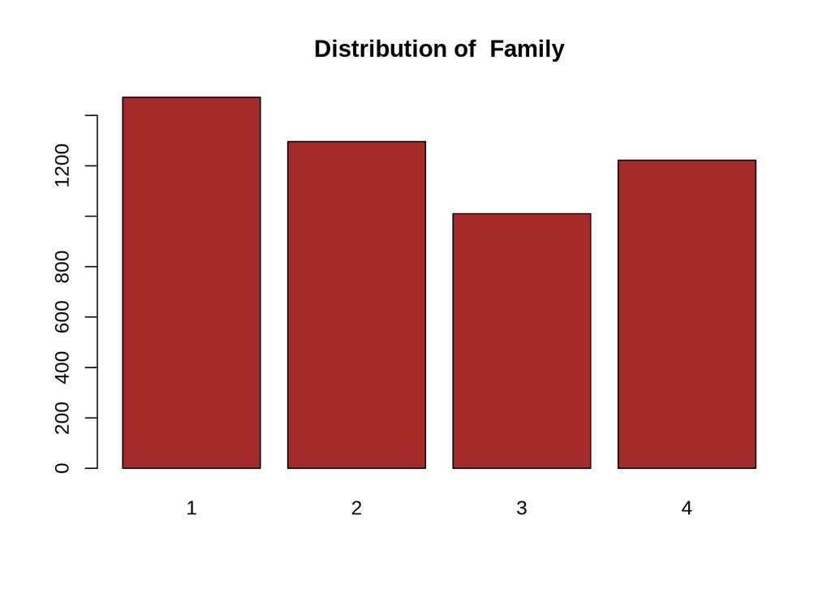

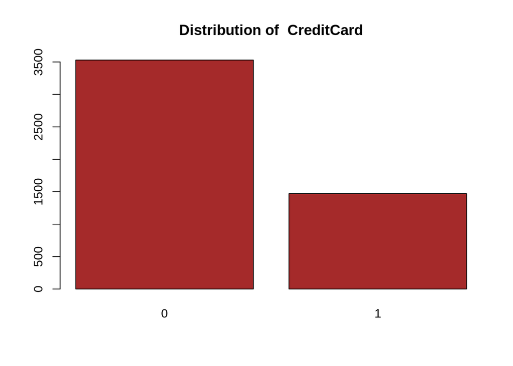

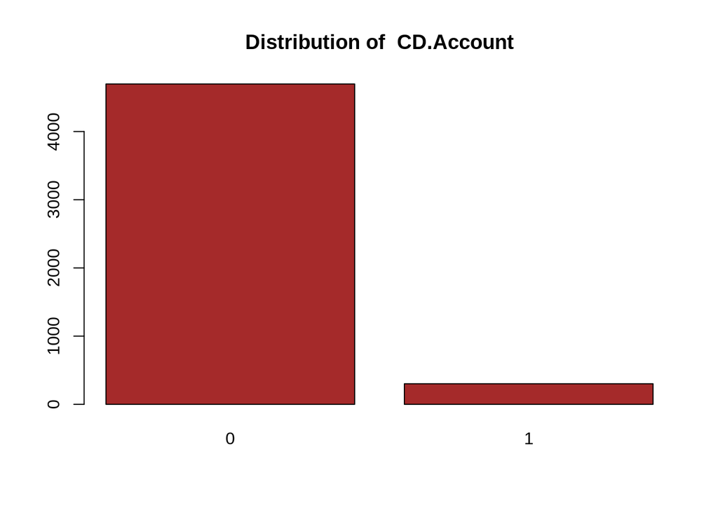

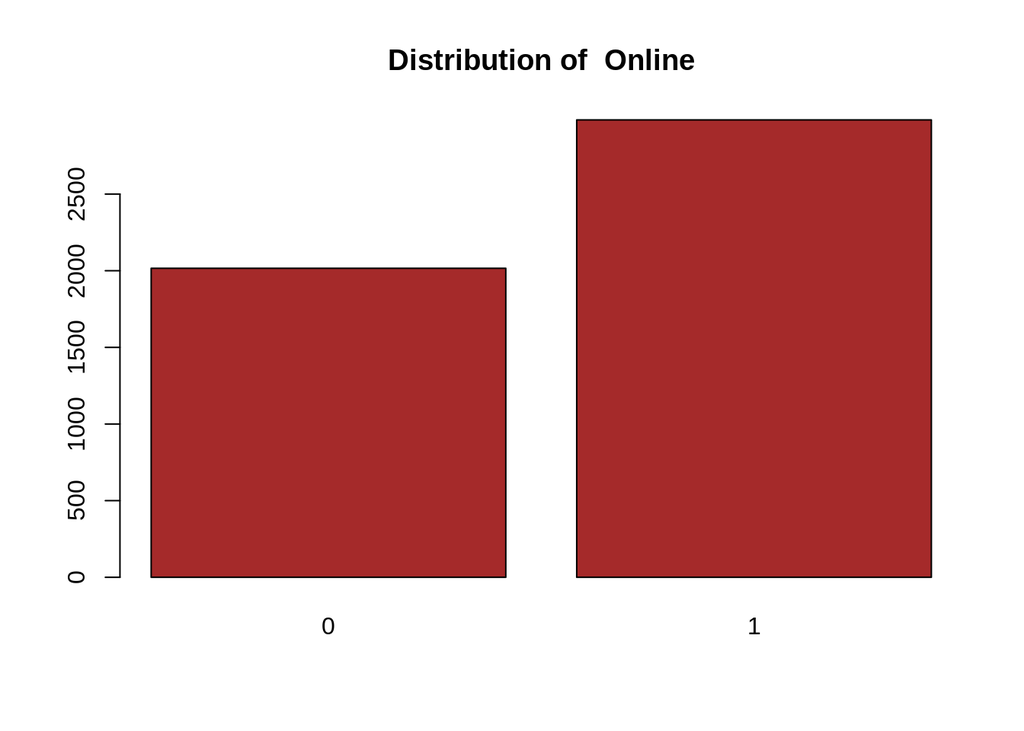

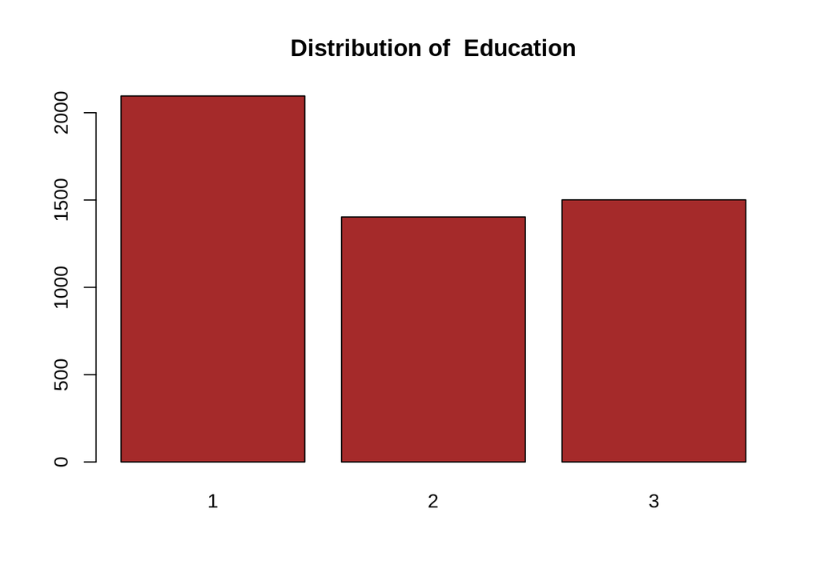

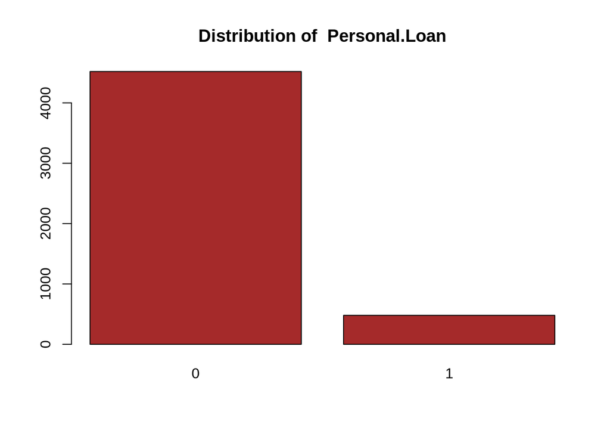

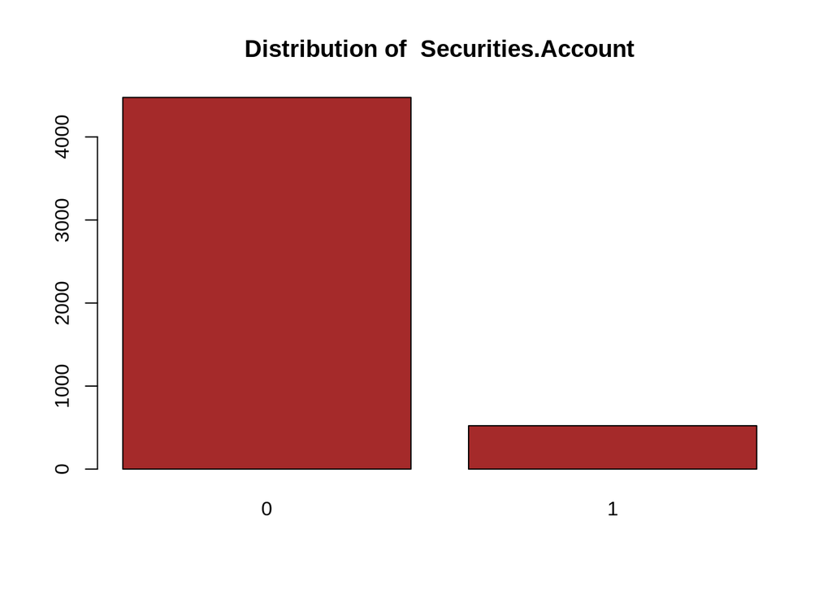

```r
for (i in cat_cols){
  if (i != "ZIP.Code")barplot(table(df[,i]),col = "brown",main = paste("Distribution of ",i))
}
```

## Boxplots

### Online and Income

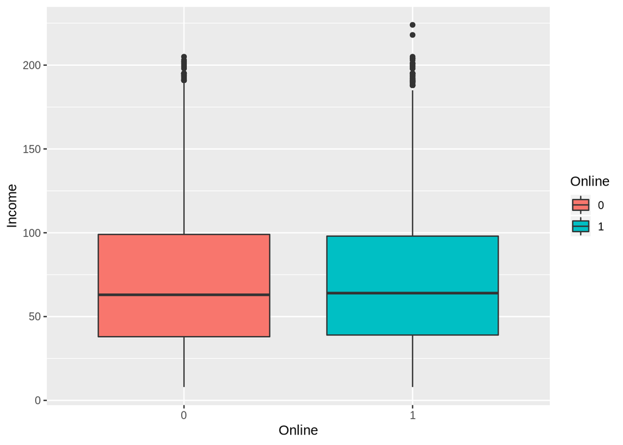

```r
library(ggplot2)
ggplot(df, aes(x=Online, y=Income)) +
  geom_boxplot(aes(fill=Online))
```

# Data Pre-processing

## Train-Test Split

- Split the data into train and test

```r
set.seed(007) # set seed for reproducible results
library(caret)
train_rows  <- createDataPartition(df$Income, p = .8,
                                  list = FALSE,
                                  times = 1)


train_data <- df[train_rows, ]

test_data <- df[-train_rows, ]
```

- Carets’ createDataPartition is not very helpful for a regression problem as the stratified sampling technique does not offer any help here, regardless we will use this method for splitting our data to maintain the flow.

## Correlation plot

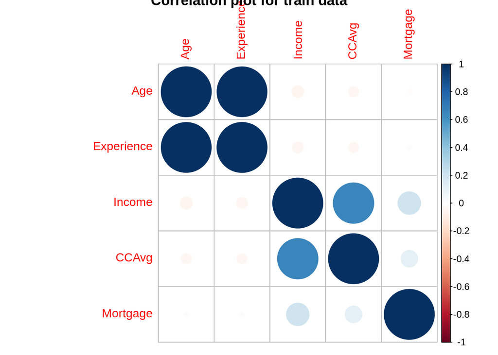

```r
library(corrplot)
corrplot(cor(train_data[num_cols],use="complete.obs"),title = "Correlation plot for train data")
```

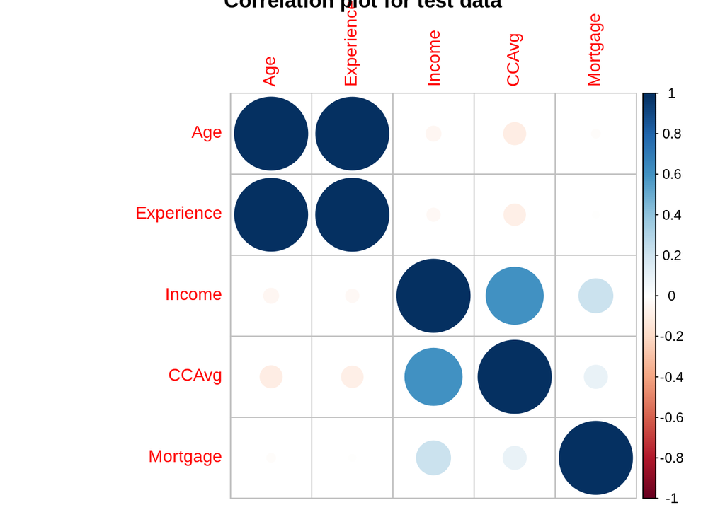

```r
corrplot(cor(test_data[num_cols],use="complete.obs"),title = "Correlation plot for test data")
```

## Imputation

```r
library(RANN)
library(DMwR)
impute_num = preProcess(x = train_data[, !colnames(train_data) %in% c("Income")], method = c("knnImpute"))
train_data = predict(impute_num, train_data)
test_data = predict(impute_num, test_data)


for (x in cat_cols){
  # print (names(which(table(train_data[,x]) == max(table(train_data[,x])))))
  subs = names(which(table(train_data[,x]) == max(table(train_data[,x]))))
  train_data[,x][is.na(train_data[,x])] = subs
  test_data[,x][is.na(test_data[,x])] = subs
}

sum(is.na(train_data))
```

```
## [1] 0
```

## Standardize the Data

```r
std_obj <- preProcess(x = train_data[, !colnames(train_data) %in% c("Income")],
                      method = c("center", "scale"))

train_std_data <- predict(std_obj, train_data)

test_std_data <- predict(std_obj, test_data)
```

```r
str(train_std_data)
```

```
## 'data.frame':    4002 obs. of  12 variables:
##  $ Age               : num  -0.542 -0.892 -0.892 -0.717 0.681 ...
##  $ Experience        : num  -0.436 -0.962 -1.05 -0.612 0.615 ...
##  $ Income            : int  11 100 45 29 72 81 45 114 40 112 ...
##  $ Family            : Factor w/ 4 levels "1","2","3","4": 1 1 4 4 2 3 3 2 4 1 ...
##  $ CCAvg             : num  -0.539 0.419 -0.539 -0.877 -0.257 ...
##  $ Education         : Factor w/ 3 levels "1","2","3": 1 2 2 2 2 2 2 3 2 1 ...
##  $ Mortgage          : num  -0.557 -0.557 -0.557 0.976 -0.557 ...
##  $ Personal.Loan     : Factor w/ 2 levels "0","1": 1 1 1 1 1 1 1 1 1 1 ...
##  $ Securities.Account: Factor w/ 2 levels "0","1": 1 1 1 1 1 1 1 2 1 2 ...
##  $ CD.Account        : Factor w/ 2 levels "0","1": 1 1 1 1 1 1 1 1 1 1 ...
##  $ Online            : Factor w/ 2 levels "0","1": 1 1 1 2 2 2 2 1 2 1 ...
##  $ CreditCard        : Factor w/ 2 levels "0","1": 1 1 2 1 1 1 1 1 1 1 ...
```

## Dummify the Data

```r
dummy_obj <- dummyVars( ~ . , train_std_data)

train_dummy_data <- as.data.frame(predict(dummy_obj, train_std_data))

test_dummy_data <- as.data.frame(predict(dummy_obj, test_std_data))
```

# Basic regression model

## Let us first build a linear regression model and test its performance

```r
model_basic <- lm(formula = Income~. , data = train_dummy_data)

summary(model_basic)
```

```
##
## Call:
## lm(formula = Income ~ ., data = train_dummy_data)
##
## Residuals:
##     Min      1Q  Median      3Q     Max
## -92.875 -22.530  -5.033  19.322 137.069
##
## Coefficients: (7 not defined because of singularities)
##                      Estimate Std. Error t value Pr(>|t|)
## (Intercept)          108.5566     2.6559  40.874  < 2e-16 ***
## Age                  -12.1438     4.6377  -2.618  0.00887 **
## Experience            10.7402     4.6329   2.318  0.02049 *
## Family.1               9.8155     1.3412   7.319 3.02e-13 ***
## Family.2              12.4143     1.3836   8.973  < 2e-16 ***
## Family.3               2.6667     1.4505   1.838  0.06607 .
## Family.4                   NA         NA      NA       NA
## CCAvg                 21.6614     0.5402  40.097  < 2e-16 ***
## Education.1           15.4095     1.2340  12.487  < 2e-16 ***
## Education.2           -0.6444     1.2819  -0.503  0.61523
## Education.3                NA         NA      NA       NA
## Mortgage               4.0732     0.4892   8.327  < 2e-16 ***
## Personal.Loan.0      -56.0914     1.9142 -29.303  < 2e-16 ***
## Personal.Loan.1            NA         NA      NA       NA
## Securities.Account.0   1.4643     1.6957   0.864  0.38789
## Securities.Account.1       NA         NA      NA       NA
## CD.Account.0           2.5523     2.4119   1.058  0.29002
## CD.Account.1               NA         NA      NA       NA
## Online.0              -1.3242     1.0039  -1.319  0.18722
## Online.1                   NA         NA      NA       NA
## CreditCard.0          -0.1492     1.1123  -0.134  0.89332
## CreditCard.1               NA         NA      NA       NA
## ---
## Signif. codes:  0 '***' 0.001 '**' 0.01 '*' 0.05 '.' 0.1 ' ' 1
##
## Residual standard error: 30.42 on 3987 degrees of freedom
## Multiple R-squared:  0.5669, Adjusted R-squared:  0.5654
## F-statistic: 372.8 on 14 and 3987 DF,  p-value: < 2.2e-16
```

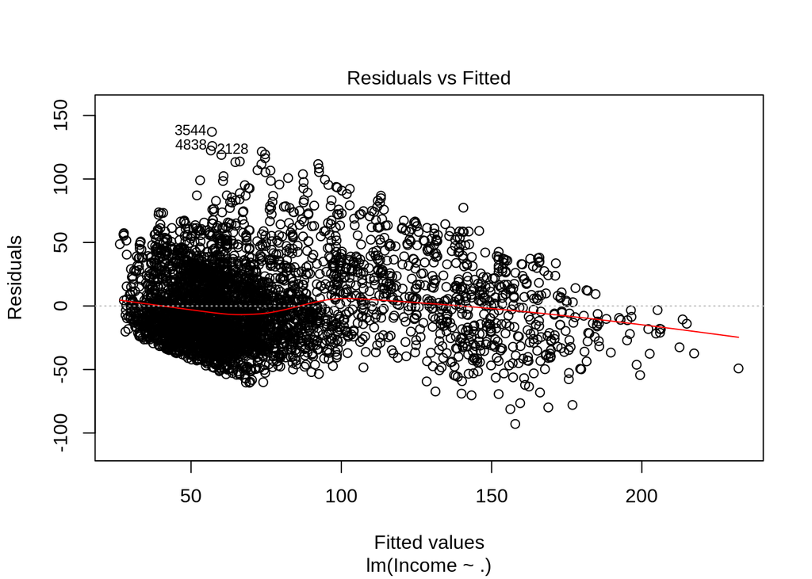

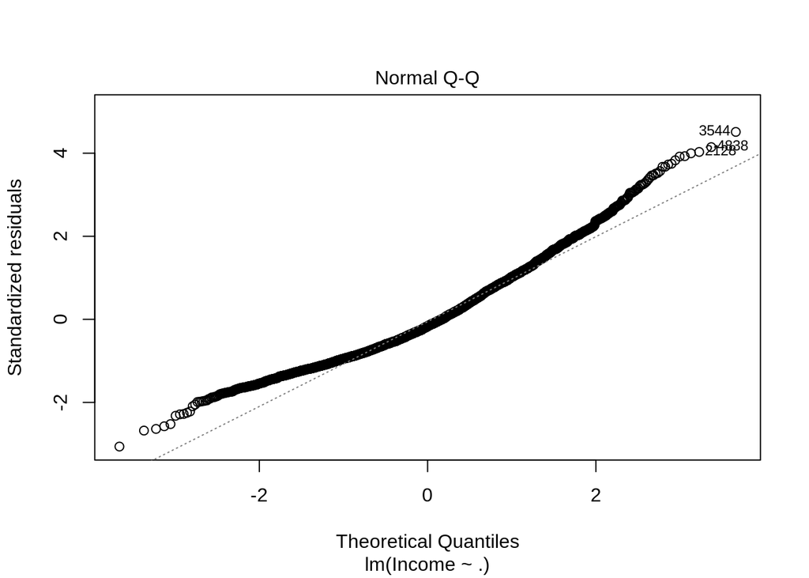

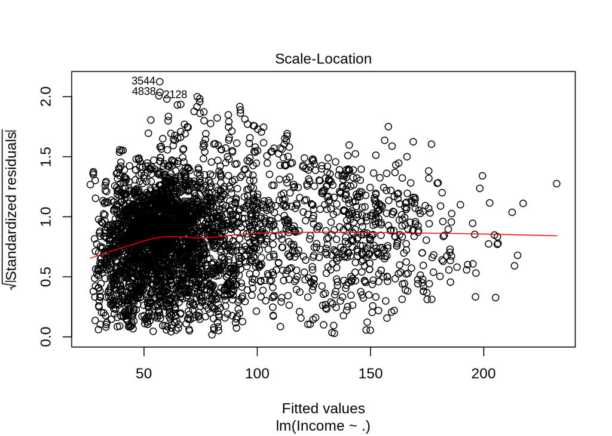

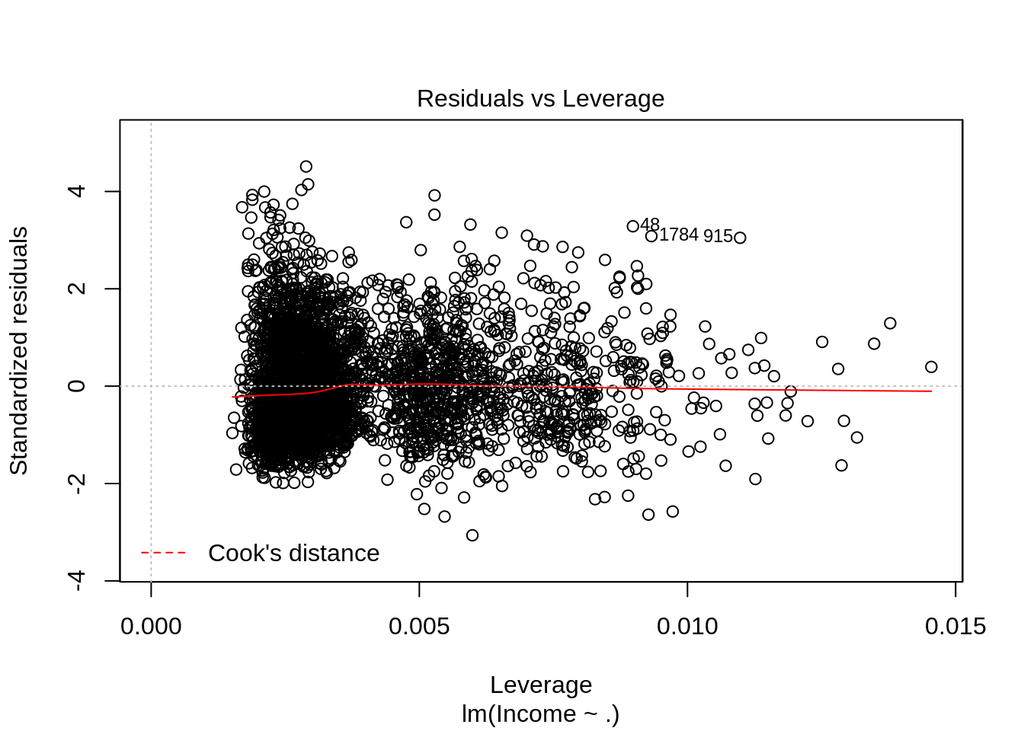

```r
# par(mfrow = c(2,2))

plot(model_basic)
```

## Prediction and evaluation of basic linear model

```r
library(DMwR)
preds_model <- predict(model_basic, test_dummy_data[, !(names(test_dummy_data) %in% c("Income"))])
# sum(is.na(train_dummy_data))
preds_train = predict(model_basic, train_dummy_data[, !(names(train_dummy_data) %in% c("Income"))])

regr.eval(trues =train_dummy_data$Income,preds = preds_train)
```

```
##       mae       mse      rmse      mape
##  24.23469 921.74599  30.36027   0.53903
```

```r
regr.eval(trues =test_dummy_data$Income,preds = preds_model)
```

```
##         mae         mse        rmse        mape
##  25.1945052 995.3968233  31.5499100   0.5710639
```

# Model Selection - Step AIC

```r
library(MASS)
model_aic <- stepAIC(model_basic, direction = "both")
```

```
## Start:  AIC=27348.73
## Income ~ Age + Experience + Family.1 + Family.2 + Family.3 +
##     Family.4 + CCAvg + Education.1 + Education.2 + Education.3 +
##     Mortgage + Personal.Loan.0 + Personal.Loan.1 + Securities.Account.0 +
##     Securities.Account.1 + CD.Account.0 + CD.Account.1 + Online.0 +
##     Online.1 + CreditCard.0 + CreditCard.1
##
##
## Step:  AIC=27348.73
## Income ~ Age + Experience + Family.1 + Family.2 + Family.3 +
##     Family.4 + CCAvg + Education.1 + Education.2 + Education.3 +
##     Mortgage + Personal.Loan.0 + Personal.Loan.1 + Securities.Account.0 +
##     Securities.Account.1 + CD.Account.0 + CD.Account.1 + Online.0 +
##     Online.1 + CreditCard.0
##
##
## Step:  AIC=27348.73
## Income ~ Age + Experience + Family.1 + Family.2 + Family.3 +
##     Family.4 + CCAvg + Education.1 + Education.2 + Education.3 +
##     Mortgage + Personal.Loan.0 + Personal.Loan.1 + Securities.Account.0 +
##     Securities.Account.1 + CD.Account.0 + CD.Account.1 + Online.0 +
##     CreditCard.0
##
##
## Step:  AIC=27348.73
## Income ~ Age + Experience + Family.1 + Family.2 + Family.3 +
##     Family.4 + CCAvg + Education.1 + Education.2 + Education.3 +
##     Mortgage + Personal.Loan.0 + Personal.Loan.1 + Securities.Account.0 +
##     Securities.Account.1 + CD.Account.0 + Online.0 + CreditCard.0
##
##
## Step:  AIC=27348.73
## Income ~ Age + Experience + Family.1 + Family.2 + Family.3 +
##     Family.4 + CCAvg + Education.1 + Education.2 + Education.3 +
##     Mortgage + Personal.Loan.0 + Personal.Loan.1 + Securities.Account.0 +
##     CD.Account.0 + Online.0 + CreditCard.0
##
##
## Step:  AIC=27348.73
## Income ~ Age + Experience + Family.1 + Family.2 + Family.3 +
```

[output cut: 141 more lines]

```
## + Online.0              1      1127 3691828 27344
## + Online.1              1      1127 3691828 27344
## - Family.3              1      2934 3695889 27344
## + Education.2           1       199 3692756 27345
## + Education.3           1       199 3692756 27345
## + CreditCard.0          1        38 3692917 27345
## + CreditCard.1          1        38 3692917 27345
## - Experience            1      4860 3697814 27346
## - Age                   1      6210 3699165 27348
## - Family.1              1     50026 3742981 27395
## - Mortgage              1     63535 3756490 27410
## - Family.2              1     74890 3767845 27422
## - Education.1           1    207290 3900244 27560
## - Personal.Loan.0       1    855098 4548053 28175
## - CCAvg                 1   1487253 5180208 28696
```

```r
summary(model_aic)
```

```
##
## Call:
## lm(formula = Income ~ Age + Experience + Family.1 + Family.2 +
##     Family.3 + CCAvg + Education.1 + Mortgage + Personal.Loan.0,
##     data = train_dummy_data)
##
## Residuals:
##     Min      1Q  Median      3Q     Max
## -91.463 -22.411  -5.077  18.999 136.453
##
## Coefficients:
##                 Estimate Std. Error t value Pr(>|t|)
## (Intercept)     110.7659     1.8273  60.616  < 2e-16 ***
## Age             -11.9067     4.5954  -2.591   0.0096 **
## Experience       10.5265     4.5928   2.292   0.0220 *
## Family.1          9.8260     1.3362   7.354 2.33e-13 ***
## Family.2         12.4162     1.3800   8.997  < 2e-16 ***
## Family.3          2.5786     1.4480   1.781   0.0750 .
## CCAvg            21.6531     0.5400  40.096  < 2e-16 ***
## Education.1      15.7043     1.0491  14.969  < 2e-16 ***
## Mortgage          4.0455     0.4882   8.287  < 2e-16 ***
## Personal.Loan.0 -55.4602     1.8242 -30.403  < 2e-16 ***
## ---
## Signif. codes:  0 '***' 0.001 '**' 0.01 '*' 0.05 '.' 0.1 ' ' 1
##
## Residual standard error: 30.42 on 3992 degrees of freedom
## Multiple R-squared:  0.5665, Adjusted R-squared:  0.5655
## F-statistic: 579.5 on 9 and 3992 DF,  p-value: < 2.2e-16
```

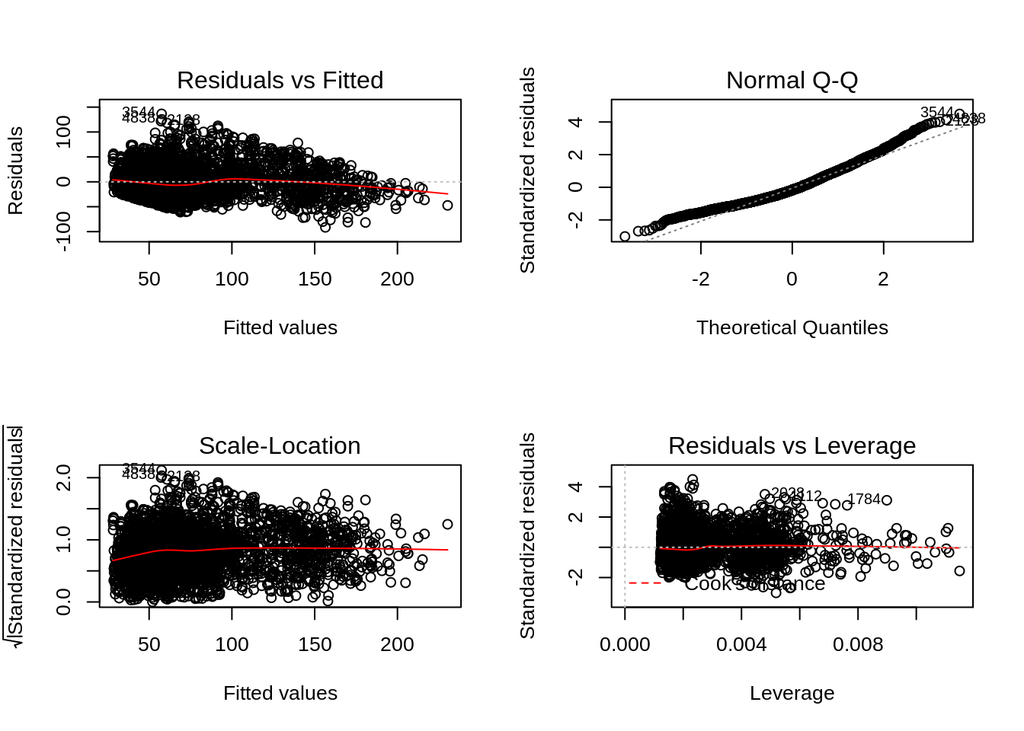

```r
par(mfrow = c(2,2))

plot(model_aic)
```

```r
preds_train = predict(model_aic, train_dummy_data[, !(names(train_dummy_data) %in% c("Income"))])

regr.eval(trues =train_dummy_data$Income,preds = preds_train)
```

```
##         mae         mse        rmse        mape
##  24.2465115 922.7772825  30.3772494   0.5396908
```

```r
preds_model <- predict(model_aic, test_dummy_data[, !(names(test_dummy_data) %in% c("Income"))])

regr.eval(trues =test_dummy_data$Income,preds = preds_model)
```

```
##         mae         mse        rmse        mape
##  25.1975302 996.4818208  31.5671003   0.5710043
```

# Regularization techniques

## Ridge and Lasso Regression

RIDGE -
$$RSS(\beta) + \lambda \sum_{j=1}^{p} \beta_j^2$$

LASSO -
$$RSS(\beta) + \lambda \sum_{j=1}^{p} |\beta_j|$$

Elastic Net -
$$RSS (\beta) + \lambda (\alpha (\sum_{j=1}^{p} |\beta_j|) + (1-\alpha)(\sum_{j=1}^{p} \beta_j^2))$$

p - number of attributes

## Get the data into a compatible format

- The functions we will be using today from the glmnet package expect a matrix as an input, so let us convert our dataframes into a matrix

```r
X_train <- as.matrix(train_dummy_data[, -3])

y_train <- as.matrix(train_dummy_data[, 3])

X_test <- as.matrix(test_dummy_data[, -3])

y_test <- as.matrix(test_dummy_data[, 3])
```

## Building the Lasso Regression Model

- I am selecting a random lambda for the initial model, we will find the best lambda using advanced techniques.

```r
library(glmnet)
lasso_model <- glmnet(X_train, y_train, lambda = 0.5, alpha = 1)

coef(lasso_model)
```

```
## 22 x 1 sparse Matrix of class "dgCMatrix"
##                                 s0
## (Intercept)           1.181760e+02
## Age                  -9.420483e-01
## Experience            .
## Family.1              .
## Family.2              2.500672e+00
## Family.3             -5.798457e+00
## Family.4             -8.333367e+00
## CCAvg                 2.153744e+01
## Education.1           1.540275e+01
## Education.2           .
## Education.3           .
## Mortgage              3.676867e+00
## Personal.Loan.0      -5.384254e+01
## Personal.Loan.1       .
## Securities.Account.0  5.121509e-01
## Securities.Account.1 -1.570836e-11
## CD.Account.0          .
## CD.Account.1          .
## Online.0             -3.201038e-02
## Online.1              .
## CreditCard.0          .
## CreditCard.1          .
```

```r
preds_train = predict(lasso_model, X_train)

regr.eval(trues =train_dummy_data$Income,preds = preds_train)
```

```
##         mae         mse        rmse        mape
##  24.3088720 925.4101221  30.4205543   0.5432273
```

```r
preds_lasso <- predict(lasso_model, X_test)

regr.eval(preds_lasso,test_dummy_data)
```

```
##          mae          mse         rmse         mape
##   1541.09419 131665.55505    362.85749     21.28068
```

## Building the Ridge Regression Model

- I am selecting a random lambda for the initial model, we will find the best lambda using advanced techniques.

```r
ridge_model <- glmnet(X_train, y_train, lambda = 0.5, alpha = 0)

coef(ridge_model)
```

```
## 22 x 1 sparse Matrix of class "dgCMatrix"
##                                s0
## (Intercept)           95.27646193
## Age                   -4.46028745
## Experience             3.06375194
## Family.1               3.60075321
## Family.2               6.18847943
## Family.3              -3.71320864
## Family.4              -6.25291153
## CCAvg                 21.39328021
## Education.1           10.58453768
## Education.2           -5.70000717
## Education.3           -5.33333477
## Mortgage               4.04879416
## Personal.Loan.0      -30.27179285
## Personal.Loan.1       25.92683125
## Securities.Account.0   0.82456369
## Securities.Account.1  -0.70373302
## CD.Account.0           1.24328510
## CD.Account.1          -1.08213305
## Online.0              -0.70473971
## Online.1               0.60571708
## CreditCard.0          -0.05180340
## CreditCard.1           0.04687114
```

```r
preds_train = predict(ridge_model, X_train)

regr.eval(trues =train_dummy_data$Income,preds = preds_train)
```

```
##         mae         mse        rmse        mape
##  24.2620069 922.4382277  30.3716682   0.5408983
```

```r
preds_ridge <- predict(ridge_model, X_test)
regr.eval(preds_ridge,test_dummy_data)
```

```
##          mae          mse         rmse         mape
##   1540.80880 132494.58744    363.99806     21.28001
```

## Finding the best lambda for Lasso Regression

- The alpha value is 1 for lasso regression
- in the plots, the numbers at the top signify the number of co-efficients which are not 0.

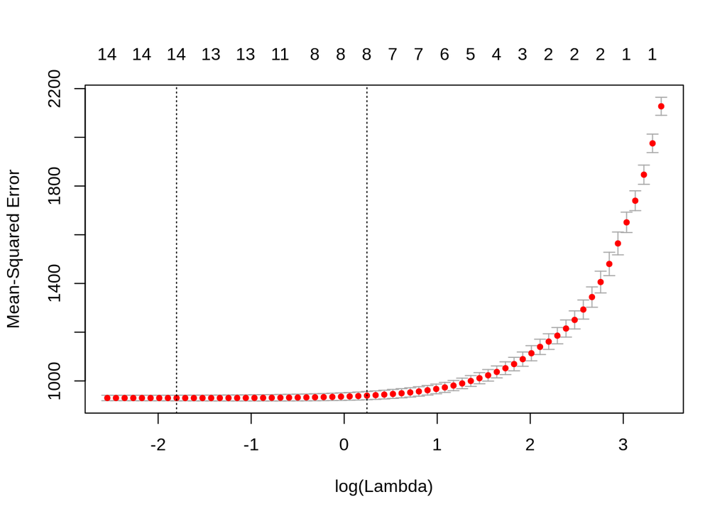

```r
library(glmnet)

cv_lasso <- cv.glmnet(X_train, y_train, alpha = 1, type.measure = "mse", nfolds = 4)

plot(cv_lasso)
```

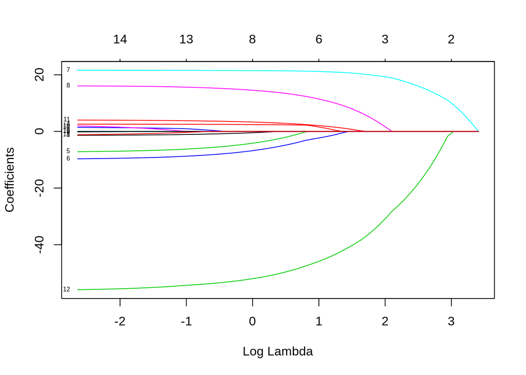

```r
plot(cv_lasso$glmnet.fit, xvar="lambda", label=TRUE)
```

- The object returned form the call to cv.glmnet() function, contains the lambda values of importance
- The coefficients are accessible calling the coef() function on the cv_lasso object
- lambda - the values of lambda used in the fits.
- cvm - The mean cross-validated error - a vector of length length(lambda).
- cvsd - estimate of standard error of cvm.
- cvup - upper curve = cvm+cvsd.
- cvlo - lower curve = cvm-cvsd.
- nzero - number of non-zero coefficients at each lambda.

```r
print(cv_lasso$lambda.min)
```

```
## [1] 0.1649402
```

```r
coef(cv_lasso)
```

```
## 22 x 1 sparse Matrix of class "dgCMatrix"
##                                1
## (Intercept)          115.5261184
## Age                   -0.1788653
## Experience             .
## Family.1               .
## Family.2               2.3842716
## Family.3              -3.2641477
## Family.4              -5.9450225
## CCAvg                 21.4414977
## Education.1           14.0703963
## Education.2            .
## Education.3            .
## Mortgage               3.1171028
## Personal.Loan.0      -50.9794016
## Personal.Loan.1        .
## Securities.Account.0   .
## Securities.Account.1   .
## CD.Account.0           .
## CD.Account.1           .
## Online.0               .
## Online.1               .
## CreditCard.0           .
## CreditCard.1           .
```

## Finding the best lambda for Ridge Regression

- The alpha value is 0 for ridge regression

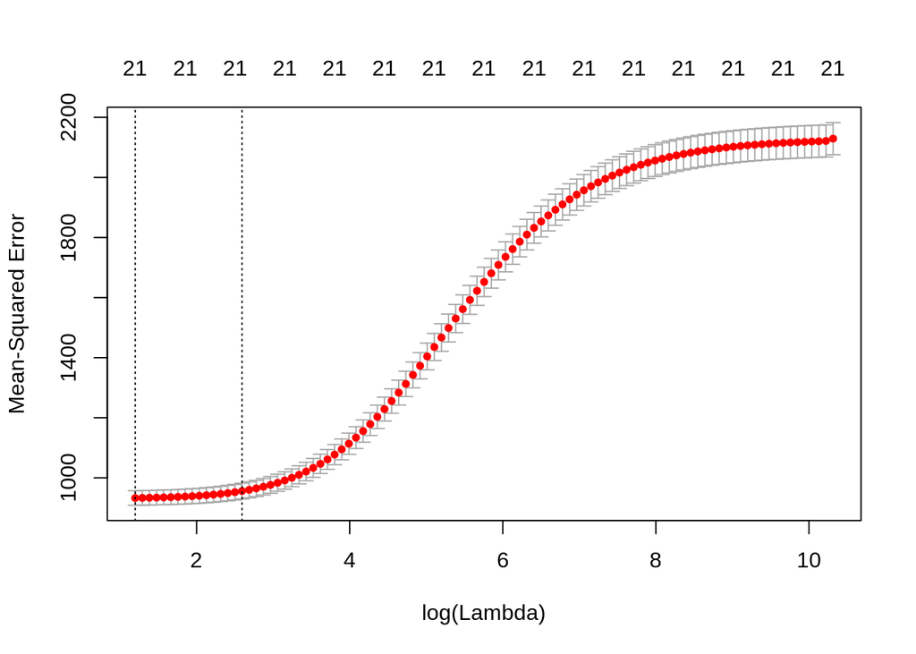

```r
cv_ridge <- cv.glmnet(X_train, y_train, alpha = 0, type.measure = "mse", nfolds = 4)

plot(cv_ridge)
```

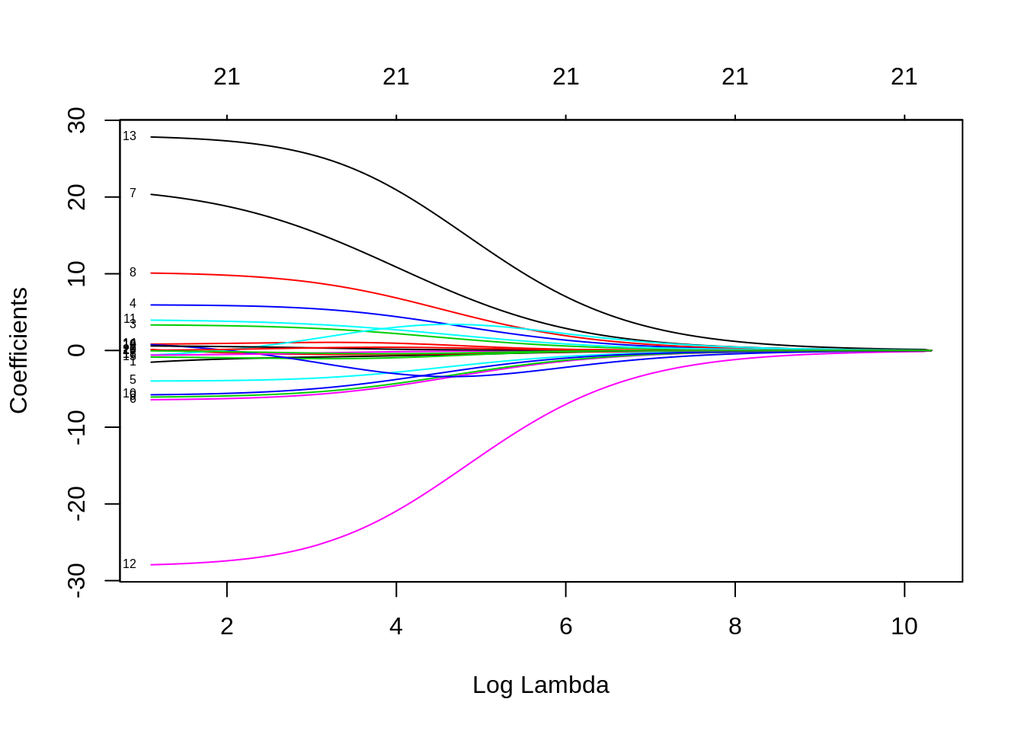

```r
plot(cv_ridge$glmnet.fit, xvar="lambda", label=TRUE)
```

- We can access the lambda and the coefficients as we did before

```r
print(cv_ridge$lambda.min)
```

```
## [1] 3.314034
```

```r
coef(cv_ridge)
```

```
## 22 x 1 sparse Matrix of class "dgCMatrix"
##                                1
## (Intercept)           94.1568118
## Age                   -0.9456881
## Experience            -0.4442522
## Family.1               3.0723120
## Family.2               5.6821293
## Family.3              -3.7913918
## Family.4              -6.0392438
## CCAvg                 17.0861459
## Education.1            9.3783578
## Education.2           -5.7008327
## Education.3           -5.3196670
## Mortgage               3.6131927
## Personal.Loan.0      -26.5715485
## Personal.Loan.1       26.4904282
## Securities.Account.0   1.0035395
## Securities.Account.1  -1.0175280
## CD.Account.0          -0.7767520
## CD.Account.1           0.8327770
## Online.0              -0.4241813
## Online.1               0.4187606
## CreditCard.0           0.2546511
## CreditCard.1          -0.2608925
```

# Building The Final Model

- By using the optimal lambda values obtained above, we can build our ridge and lasso models

## Building the Final Lasso Regression Model

```r
lasso_model <- glmnet(X_train, y_train, lambda = cv_lasso$lambda.min, alpha = 1)

coef(lasso_model)
```

```
## 22 x 1 sparse Matrix of class "dgCMatrix"
##                                 s0
## (Intercept)           1.115341e+02
## Age                  -1.280680e+00
## Experience            .
## Family.1              6.703264e+00
## Family.2              9.283041e+00
## Family.3             -1.517758e-01
## Family.4             -2.667231e+00
## CCAvg                 2.158039e+01
## Education.1           1.596158e+01
## Education.2          -6.458688e-02
## Education.3           .
## Mortgage              3.933624e+00
## Personal.Loan.0      -5.540454e+01
## Personal.Loan.1       .
## Securities.Account.0  1.276576e+00
## Securities.Account.1 -2.432836e-12
## CD.Account.0          1.315215e+00
## CD.Account.1         -1.038436e-11
## Online.0             -8.767103e-01
## Online.1              .
## CreditCard.0          .
## CreditCard.1          .
```

```r
cv_lasso$lambda.min
```

```
## [1] 0.1649402
```

- Use the model to predict on test data

```r
preds_lasso <- predict(lasso_model, X_test)
```

## Lasso Regression Model Metrics

```r
library(DMwR)
preds_train = predict(lasso_model, X_train)

regr.eval(trues =train_dummy_data$Income,preds = preds_train)
```

```
##         mae         mse        rmse        mape
##  24.2703580 923.2855431  30.3856141   0.5406332
```

```r
regr.eval(trues = y_test, preds = preds_lasso)
```

```
##         mae         mse        rmse        mape
##  25.2242720 995.7513498  31.5555280   0.5709309
```

## Building the Final Ridge Regression Model

```r
ridge_model <- glmnet(X_train, y_train, lambda = cv_ridge$lambda.min, alpha = 0)

coef(ridge_model)
```

```
## 22 x 1 sparse Matrix of class "dgCMatrix"
##                                s0
## (Intercept)           94.24893516
## Age                   -1.53840640
## Experience             0.13665639
## Family.1               3.34495287
## Family.2               5.95414145
## Family.3              -3.95158053
## Family.4              -6.38782030
## CCAvg                 20.22347784
## Education.1           10.11130276
## Education.2           -6.02102533
## Education.3           -5.72436923
## Mortgage               3.94331563
## Personal.Loan.0      -28.10605658
## Personal.Loan.1       27.60317479
## Securities.Account.0   0.86320598
## Securities.Account.1  -0.83952187
## CD.Account.0           0.61149182
## CD.Account.1          -0.63340609
## Online.0              -0.59568310
## Online.1               0.58745426
## CreditCard.0           0.04887138
## CreditCard.1          -0.04353616
```

- Use the model to predict on test data

```r
preds_ridge <- predict(ridge_model, X_test)
```

## Ridge Regression Model Metrics

```r
library(DMwR)

preds_train = predict(ridge_model,X_train)

regr.eval(trues =train_dummy_data$Income,preds = preds_train)
```

```
##         mae         mse        rmse        mape
##  24.3540259 925.1754604  30.4166971   0.5498136
```

```r
regr.eval(trues = y_test, preds = preds_ridge)
```

```
##         mae         mse        rmse        mape
##  25.2760941 996.1529236  31.5618904   0.5799739
```

# Elastic Net Model

```r
library(glmnet)
# Grid search
sampling_strategy <- trainControl(method = "cv", number = 5)
elastic_net_model <- train(Income ~ ., train_dummy_data,
                           method = "glmnet",
                           trControl = sampling_strategy,
                           metric = "RMSE",
                           tuneGrid =
                             expand.grid(.alpha = seq(.05,
                                                      1,
                                              length = 10),
                                  .lambda = c((1:20)/10)))
```

```r
# elastic_net_model$finalModel
```

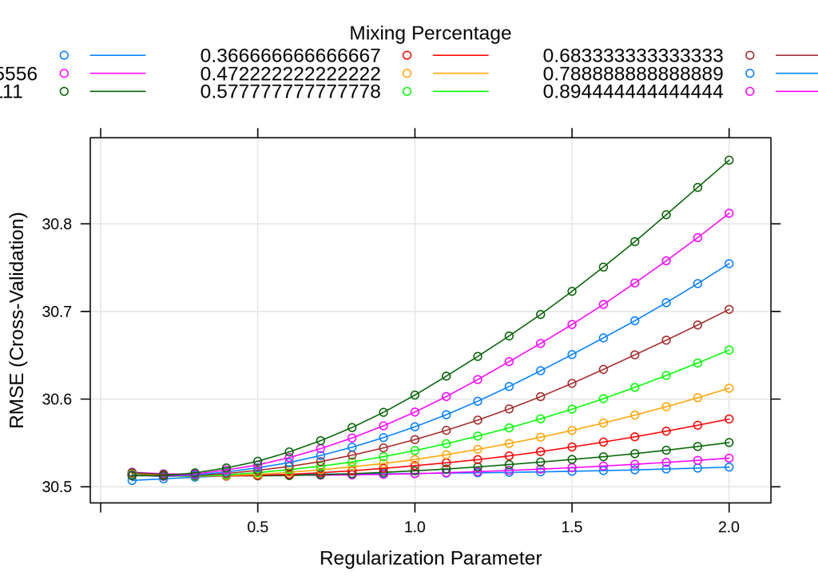

```r
plot(elastic_net_model)
```

### Evaluate the Elastic Net Model

```r
preds_train = predict(elastic_net_model, train_dummy_data[, !(names(train_dummy_data) %in% c("Income"))])

regr.eval(trues =train_dummy_data$Income,preds = preds_train)
```

```
##         mae         mse        rmse        mape
##  24.2445535 921.9921467  30.3643236   0.5394902
```

```r
preds_elastic <- predict(elastic_net_model, test_dummy_data)
regr.eval(trues = test_dummy_data[, 3], preds = preds_elastic)
```

```
##         mae         mse        rmse        mape
##  25.1996334 994.6405984  31.5379232   0.5708349
```